# NIFTY50 Stock Analysis

## Key Steps:

**Step 1: Web Scraping (To get the name, ticker and sector for top 50 Indian Companies).**

**Step 2: Definition of Stock() Class using OOP concepts which contains the required Attributes & Methods. Benchmark & Active Stock Selection Strategy.**

**Step 3: Calculation of CAGR%, Volatility%, Sharpe Ratio & Max DrawDown %.**

**Step 4: Comparision of Top 3 stocks (based on CAGR%) with NIFTY50 Index.**

```python
import numpy as np
import pandas as pd
from pandas import Series, DataFrame
```

```python
import matplotlib.pyplot as plt
import seaborn as sns

sns.set_style('whitegrid')
%matplotlib inline
```

```python
import yfinance as yf
```

```python
import datetime as dt
from datetime import datetime, date
from calendar import month_name
```

```python
from bs4 import BeautifulSoup
import requests
```

.

## Web Scraping

```python
url = 'https://en.wikipedia.org/wiki/NIFTY_50'

response = requests.get(url)
soup = BeautifulSoup(response.text, "html.parser")
```

```python
table_row = soup.find('table', id="constituents").find_all('tr')
len(table_row)
```

```
51
```

```python
company = []
symbol = []
sector = []
```

```python
for row in table_row[1:]:

    key = row.find_all('td')

    company.append(key[0].get_text().strip())
    symbol.append(key[1].get_text().strip())
    sector.append(key[2].get_text().strip())
```

```python
n50 = pd.DataFrame({'Company': company,
                  'Ticker': symbol,
                  'Sector': sector})
```

```python
n50.head(3)
```

|  | Company | Ticker | Sector |
| --- | --- | --- | --- |
| 0 | Adani Enterprises | ADANIENT | Diversified |
| 1 | Adani Ports & SEZ | ADANIPORTS | Infrastructure |
| 2 | Apollo Hospitals | APOLLOHOSP | Healthcare |

```python
n50.tail(3)
```

|  | Company | Ticker | Sector |
| --- | --- | --- | --- |
| 47 | UltraTech Cement | ULTRACEMCO | Materials |
| 48 | UPL | UPL | Chemicals |
| 49 | Wipro | WIPRO | Information Technology |

### Few Global Variables

```python
n50_list = n50['Ticker']

global n50_list
```

```python
start_date = dt.date(2021, 1, 1)
global start_date
```

```python
end_date = date.today()
global end_date
```

`

## Definition of Stock() Class

***Attributes for the class:***

- **ticker**
- **start_date**
- **end_date**
- **equity (default value is 1000000)**

***Method of this class should be:***

- **1. CurPrice(curDate) – Which gives the closing price of the date curDate.**
- **2. NDayRet(N,curDate) – Which gives the N-day returns as on the curDate. (N=5 will give 5-day return)**
- **3. DailyRet(curDate) - Which gives the daily returns on curDate.**
- **4. Last30daysPrice(curDate) – Which gives the array of last 30 days prices.**

```python
class Stock:

    def __init__(self, ticker, start_date, end_date, equity=1000000):
        self.ticker = ticker
        self.start_date = start_date
        self.end_date = end_date
        self.equity = equity
        self.stock_info_df = self.price_history_dataframe()


    def price_history_dataframe(self):
        start_date = self.start_date
        end_date = self.end_date
        try:
            ticker = self.ticker # +'.NS'
            data = yf.download(ticker, start=start_date, end=end_date)
            return data
        except Exception as e:
            return f'ERROR in downloading: {e}'


    def CurPrice(self, curDate):
        '''returns the closing price for the curDate'''
        try:
            closing_price  = self.stock_info_df['Close']
            return f'Closing price on {curDate}: {closing_price.loc[curDate]}'
        except:
            return f'Maybe market is closed...try for next date'


    def NDayRet(self, N, curDate):
        '''returns the N-day returns as on the curDate. (N=5 will give 5-day return)'''
        try:
            adj_close = self.stock_info_df['Adj Close']
            NdayReturn = adj_close.pct_change(N)
            return f'Return for last {N} day on {curDate}: {NdayReturn[curDate]}'
        except:
             return f'Try for different N or date value'


    def DailyRet(self, curDate):
        '''gives the daily returns on curDate.'''
        adj_close = self.stock_info_df['Adj Close']
        daily_return = adj_close.pct_change(1)
        return f'Daily return for {curDate} is: {daily_return[curDate]}'


    def Last30daysPrice(self, curDate):
        '''returns the array of last 30 days prices'''
        closing_price  = self.stock_info_df['Close']
        min_idx = min(closing_price.index)
        max_idx =  curDate
        try:
            if len(closing_price[min_idx : max_idx]) <=30:
                return np.array(closing_price[min_idx : max_idx])
            else:
                max_idx = datetime.strptime(max_idx, '%Y-%m-%d')
                min_idx = max_idx - dt.timedelta(days=30)
                return np.array(closing_price[min_idx : max_idx])
        except:
            return f'Try for different N or date value'
```

### *Object for class Stock()*

```python
# RELIANCE (object) : an instance of a class Stock()
RELIANCE = Stock(ticker='RELIANCE.NS', start_date=start_date, end_date=end_date)
```

```
[*********************100%%**********************]  1 of 1 completed
```

```python
RELIANCE
```

```
<__main__.Stock at 0x1c9e61f2340>
```

### *Attributes for class*

```python
# attributes
print('Ticker: ', RELIANCE.ticker)
print('Start Date: ', RELIANCE.start_date)
print('End Date: ', RELIANCE.end_date)
print('Equity: ', RELIANCE.equity)
print()
print('Reliance historical dataset: \n', RELIANCE.stock_info_df.head())
```

```
Ticker:  RELIANCE.NS
Start Date:  2021-01-01
End Date:  2024-01-08
Equity:  1000000

Reliance historical dataset:
                    Open         High          Low        Close    Adj Close  \
Date
2021-01-01  1988.000000  1997.000000  1982.000000  1987.500000  1968.227539
2021-01-04  1995.099976  1998.900024  1968.000000  1990.849976  1971.545044
2021-01-05  1969.000000  1983.599976  1956.000000  1966.099976  1947.035034
2021-01-06  1965.900024  1966.000000  1905.150024  1914.250000  1895.687866
2021-01-07  1920.500000  1945.000000  1905.150024  1911.150024  1892.617920

              Volume
Date
2021-01-01   4622002
2021-01-04  11312992
2021-01-05  11132803
2021-01-06  21414270
2021-01-07  14918406
```

### *Methods for class*

```python
N = 20
current_date = '2024-01-01'
```

```python
RELIANCE.CurPrice(curDate=current_date)
```

```
'Closing price on 2024-01-01: 2590.25'
```

```python
RELIANCE.NDayRet(N=N, curDate=current_date)
```

```
'Return for last 20 day on 2024-01-01: 0.08184018175490637'
```

```python
RELIANCE.DailyRet(curDate=current_date)
```

```
'Daily return for 2024-01-01 is: 0.0020503487217313765'
```

```python
RELIANCE.Last30daysPrice(curDate=current_date)
```

```
array([2420.19995117, 2437.75      , 2461.10009766, 2457.05004883,
       2455.75      , 2459.35009766, 2424.05004883, 2433.94995117,
       2464.14990234, 2495.60009766, 2521.        , 2558.10009766,
       2527.14990234, 2562.55004883, 2565.05004883, 2578.05004883,
       2586.85009766, 2605.55004883, 2584.94995117, 2590.25      ])
```

`

`

## 2. Active stock selection strategy:

Your task involves creating an investment strategy where, at the end of each month, the performance of each stock in the previous month is assessed. The criterion for selection is positive returns. For instance, on March 31st of a given year, the 30-day returns of all fifty stocks will be examined, and only those with positive returns will be included in the portfolio. This portfolio will be maintained until April 30th, when a revaluation will occur based on the same rule for the upcoming month. This process will be repeated monthly

```python
def get_n50_dataframe():
    dataframe_list = []

    for item in n50_list:
        globals()[item] = Stock(ticker=item+'.NS', start_date=start_date, end_date=end_date)
        dataframe_list.append((item, globals()[item]))

    return dataframe_list
```

```python
n50_dataframe_list = get_n50_dataframe()

global n50_dataframe_list
```

[output not shown]

```python
def modified_dataframe_list():
    arr = []
    for item, value in n50_dataframe_list:
        item = value.stock_info_df
        item.reset_index(names='Date', inplace=True)
        item['Day'] = item['Date'].dt.day
        item['Month'] = item['Date'].dt.month
        item['Month Name'] = pd.to_datetime(item['Month'], format='%m').dt.strftime('%B')
        item['Year'] = item['Date'].dt.year
        arr.append(item)
    return arr
```

```python
stock_arr = modified_dataframe_list()
```

```python
def monthly_positive_return_stock_list():
    positive_ret_stocks = []

    months = list(month_name[1:])
    years = [j for j in range(start_date.year, end_date.year + 1)]

    try:
        for year in years:
            for month in months:
                print(f'Return for {month}-{year}:')
                print()
                for name, df in zip(n50_list, stock_arr):
                    fst_val = df[(df['Year']==year) & (df['Month Name']==month)].head(1)['Adj Close'].values[0]
                    lst_val = df[(df['Year']==year) & (df['Month Name']==month)].tail(1)['Adj Close'].values[0]
                    month_return = lst_val/fst_val - 1

                    if month_return > 0:
                        positive_ret_stocks.append(name)
                        print(f'Return for {name}: {month_return}')
                print()
                print(positive_ret_stocks)
                positive_ret_stocks.clear()
                print('-'*80)
                print()

    except:
        return f'wait for next month to complete'
```

```python
print(monthly_positive_return_stock_list())
```

```
Return for January-2021:

Return for ADANIENT: 0.03155858384730581
Return for ADANIPORTS: 0.011610592115651963
Return for APOLLOHOSP: 0.06062484347672026
Return for AXISBANK: 0.06268047895305684
Return for BAJAJ-AUTO: 0.15067855841863187
Return for BPCL: 0.004319671709751116
Return for BHARTIARTL: 0.07463834281941506
Return for EICHERMOT: 0.07928592323822303
Return for GRASIM: 0.13097266794857743
Return for HEROMOTOCO: 0.04944169972373125
Return for ICICIBANK: 0.0180094352736484
Return for LT: 0.029067064917462693
Return for LTIM: 0.07152689442153504
Return for M&M: 0.023414527310697597
Return for SBIN: 0.009663590148369705
Return for TATAMOTORS: 0.40857905489512114
Return for TCS: 0.06455069625137244
Return for ULTRACEMCO: 0.006889408724048307
Return for UPL: 0.19465163405937247
Return for WIPRO: 0.07920520866779301

['ADANIENT', 'ADANIPORTS', 'APOLLOHOSP', 'AXISBANK', 'BAJAJ-AUTO', 'BPCL', 'BHARTIARTL', 'EICHERMOT', 'GRASIM', 'HEROMOTOCO', 'ICICIBANK', 'LT', 'LTIM', 'M&M', 'SBIN', 'TATAMOTORS', 'TCS', 'ULTRACEMCO', 'UPL', 'WIPRO']
--------------------------------------------------------------------------------

Return for February-2021:

Return for ADANIENT: 0.5518429035544616
Return for ADANIPORTS: 0.24532468702772903
Return for APOLLOHOSP: 0.14835749839694068
Return for AXISBANK: 0.021780555283348768
Return for BAJFINANCE: 0.04078188107874925
Return for BPCL: 0.19022063086382457
Return for COALINDIA: 0.1798447849415008
Return for GRASIM: 0.0667614447995244
Return for HDFCBANK: 0.039038440579271416
Return for HDFCLIFE: 0.002288764595742121
Return for HINDALCO: 0.4109474589431783
Return for INDUSINDBK: 0.095147389311099
```

[output cut: 1207 more lines]

```
Return for POWERGRID: 0.012591815320041944
Return for RELIANCE: 0.0067367826163016176
Return for SBILIFE: 0.015397003843326873
Return for SBIN: 0.0009355837591566996
Return for SUNPHARMA: 0.0317000207672089
Return for TATAMOTORS: 0.0004427480798165906
Return for TATACONSUM: 0.03967223086241822
Return for TITAN: 0.009627061018592675

['ADANIENT', 'ADANIPORTS', 'APOLLOHOSP', 'AXISBANK', 'BAJAJ-AUTO', 'BAJFINANCE', 'BAJAJFINSV', 'BPCL', 'BHARTIARTL', 'CIPLA', 'COALINDIA', 'DIVISLAB', 'DRREDDY', 'INDUSINDBK', 'ITC', 'NTPC', 'ONGC', 'POWERGRID', 'RELIANCE', 'SBILIFE', 'SBIN', 'SUNPHARMA', 'TATAMOTORS', 'TATACONSUM', 'TITAN']
--------------------------------------------------------------------------------

Return for February-2024:

wait for next month to complete
```

```python
n50_dataframe_list = get_n50_dataframe()
```

[output not shown]

## CAGR% (Compound Annual Growth Rate%)

```python
def CAGR():
    company_list = []
    cagr_list = []


    for item, value in n50_dataframe_list:

            df = value.stock_info_df
            time_min, time_max = df.index.min(), df.index.max()
            time_diff = time_max - time_min
            time_period = time_diff.days/365

            Vbegin = df[df.index == df.index.min()]['Adj Close'][0]
            Vfinal = df[df.index == df.index.max()]['Adj Close'][0]

            if time_period == 0:
                time_period = 1
                cagr = ((Vfinal/Vbegin)**(1/time_period) - 1) * 100

                company_list.append(item)
                cagr_list.append(cagr)
            else:
                cagr = ((Vfinal/Vbegin)**(1/time_period) - 1) * 100

                company_list.append(item)
                cagr_list.append(cagr)


    cagr_df = pd.DataFrame({'Stock': company_list,
                                 'CAGR%': cagr_list})
    return cagr_df
```

```python
CAGR()
```

|  | Stock | CAGR% |
| --- | --- | --- |
| 0 | ADANIENT | 82.625574 |
| 1 | ADANIPORTS | 32.596466 |
| 2 | APOLLOHOSP | 33.716309 |
| 3 | ASIANPAINT | 7.275315 |
| 4 | AXISBANK | 22.165588 |
| 5 | BAJAJ-AUTO | 31.647245 |
| 6 | BAJFINANCE | 13.924583 |
| 7 | BAJAJFINSV | 24.413440 |
| 8 | BPCL | 14.034309 |
| 9 | BHARTIARTL | 26.923750 |
| 10 | BRITANNIA | 15.917648 |
| 11 | CIPLA | 16.548744 |
| 12 | COALINDIA | 56.723078 |
| 13 | DIVISLAB | 2.077362 |
| 14 | DRREDDY | 4.686026 |
| 15 | EICHERMOT | 15.952963 |
| 16 | GRASIM | 30.967874 |
| 17 | HCLTECH | 19.229925 |
| 18 | HDFCBANK | 6.626071 |
| 19 | HDFCLIFE | -1.278487 |
| 20 | HEROMOTOCO | 11.976731 |
| 21 | HINDALCO | 35.909412 |
| 22 | HINDUNILVR | 4.970934 |
| 23 | ICICIBANK | 24.111219 |
| 24 | INDUSINDBK | 23.097486 |
| 25 | INFY | 9.599787 |
| 26 | ITC | 35.489689 |
| 27 | JSWSTEEL | 32.238107 |
| 28 | KOTAKBANK | -2.439364 |
| 29 | LT | 40.562582 |
| 30 | LTIM | 18.420389 |
| 31 | M&M | 32.137516 |
| 32 | MARUTI | 9.981853 |
| 33 | NESTLEIND | -46.757043 |
| 34 | NTPC | 54.606276 |
| 35 | ONGC | 41.857610 |
| 36 | POWERGRID | 41.349413 |
| 37 | RELIANCE | 9.794151 |
| 38 | SBILIFE | 17.748953 |
| 39 | SBIN | 33.758635 |
| 40 | SUNPHARMA | 31.002447 |
| 41 | TATAMOTORS | 61.750009 |
| 42 | TATASTEEL | 32.104134 |
| 43 | TCS | 10.525741 |
| 44 | TATACONSUM | 24.055299 |
| 45 | TECHM | 13.255934 |
| 46 | TITAN | 33.816636 |
| 47 | ULTRACEMCO | 24.234138 |
| 48 | UPL | 8.880608 |
| 49 | WIPRO | 6.060659 |

## Volatility %

```python
def volatility():
    company_list = []
    volatility_list = []

    for item, value in n50_dataframe_list:

        df = value.stock_info_df
        df['Daily Return'] = df['Adj Close'].pct_change().fillna(0)

        daily_ret_std = df['Daily Return'].std()
        vol = np.sqrt(252) * daily_ret_std * 100

        company_list.append(item)
        volatility_list.append(vol)

    volatility_df = pd.DataFrame({'Stock': company_list,
                                  'Volatility%': volatility_list})
    return volatility_df
```

```python
volatility()
```

|  | Stock | Volatility% |
| --- | --- | --- |
| 0 | ADANIENT | 55.844903 |
| 1 | ADANIPORTS | 40.823877 |
| 2 | APOLLOHOSP | 32.005237 |
| 3 | ASIANPAINT | 23.942802 |
| 4 | AXISBANK | 26.404747 |
| 5 | BAJAJ-AUTO | 23.836233 |
| 6 | BAJFINANCE | 30.261686 |
| 7 | BAJAJFINSV | 30.570482 |
| 8 | BPCL | 25.381874 |
| 9 | BHARTIARTL | 23.249400 |
| 10 | BRITANNIA | 19.741928 |
| 11 | CIPLA | 23.150131 |
| 12 | COALINDIA | 30.764819 |
| 13 | DIVISLAB | 27.507069 |
| 14 | DRREDDY | 22.695879 |
| 15 | EICHERMOT | 27.364392 |
| 16 | GRASIM | 24.912615 |
| 17 | HCLTECH | 24.134717 |
| 18 | HDFCBANK | 22.454959 |
| 19 | HDFCLIFE | 25.867718 |
| 20 | HEROMOTOCO | 25.175183 |
| 21 | HINDALCO | 37.273318 |
| 22 | HINDUNILVR | 20.327701 |
| 23 | ICICIBANK | 24.052343 |
| 24 | INDUSINDBK | 33.958395 |
| 25 | INFY | 24.208057 |
| 26 | ITC | 21.505773 |
| 27 | JSWSTEEL | 32.167874 |
| 28 | KOTAKBANK | 23.369697 |
| 29 | LT | 23.439344 |
| 30 | LTIM | 33.282535 |
| 31 | M&M | 27.832509 |
| 32 | MARUTI | 24.208945 |
| 33 | NESTLEIND | 55.274161 |
| 34 | NTPC | 25.220828 |
| 35 | ONGC | 32.292663 |
| 36 | POWERGRID | 25.945963 |
| 37 | RELIANCE | 24.052443 |
| 38 | SBILIFE | 23.583375 |
| 39 | SBIN | 27.443018 |
| 40 | SUNPHARMA | 21.811287 |
| 41 | TATAMOTORS | 38.551145 |
| 42 | TATASTEEL | 35.417585 |
| 43 | TCS | 20.958235 |
| 44 | TATACONSUM | 23.154900 |
| 45 | TECHM | 28.177906 |
| 46 | TITAN | 25.411381 |
| 47 | ULTRACEMCO | 24.188846 |
| 48 | UPL | 28.983363 |
| 49 | WIPRO | 25.333529 |

## Sharpe Ratio

```python
def sharpe_ratio():
    company_list = []
    sharpe_ratio_list = []

    for item, value in n50_dataframe_list:

        df = value.stock_info_df
        df['Daily Return'] = df['Adj Close'].pct_change().fillna(0)

        daily_ret_std = df['Daily Return'].std()
        daily_ret_mean = df['Daily Return'].mean()

        sh_ratio = np.sqrt(252) * (daily_ret_mean / daily_ret_std)

        company_list.append(item)
        sharpe_ratio_list.append(sh_ratio)

    sharpe_ratio_df = pd.DataFrame({'Stock': company_list,
                                  'Sharpe Ratio': sharpe_ratio_list})
    return sharpe_ratio_df
```

```python
sharpe_ratio()
```

|  | Stock | Sharpe Ratio |
| --- | --- | --- |
| 0 | ADANIENT | 1.383524 |
| 1 | ADANIPORTS | 0.909346 |
| 2 | APOLLOHOSP | 1.081438 |
| 3 | ASIANPAINT | 0.418008 |
| 4 | AXISBANK | 0.903157 |
| 5 | BAJAJ-AUTO | 1.291817 |
| 6 | BAJFINANCE | 0.588785 |
| 7 | BAJAJFINSV | 0.878433 |
| 8 | BPCL | 0.653364 |
| 9 | BHARTIARTL | 1.159231 |
| 10 | BRITANNIA | 0.859369 |
| 11 | CIPLA | 0.788173 |
| 12 | COALINDIA | 1.639029 |
| 13 | DIVISLAB | 0.214251 |
| 14 | DRREDDY | 0.319374 |
| 15 | EICHERMOT | 0.686349 |
| 16 | GRASIM | 1.226496 |
| 17 | HCLTECH | 0.862130 |
| 18 | HDFCBANK | 0.402331 |
| 19 | HDFCLIFE | 0.078849 |
| 20 | HEROMOTOCO | 0.582874 |
| 21 | HINDALCO | 1.023107 |
| 22 | HINDUNILVR | 0.344088 |
| 23 | ICICIBANK | 1.032684 |
| 24 | INDUSINDBK | 0.791746 |
| 25 | INFY | 0.506768 |
| 26 | ITC | 1.544433 |
| 27 | JSWSTEEL | 1.045163 |
| 28 | KOTAKBANK | 0.009149 |
| 29 | LT | 1.595001 |
| 30 | LTIM | 0.681680 |
| 31 | M&M | 1.157357 |
| 32 | MARUTI | 0.520400 |
| 33 | NESTLEIND | -0.288662 |
| 34 | NTPC | 1.883803 |
| 35 | ONGC | 1.263095 |
| 36 | POWERGRID | 1.486687 |
| 37 | RELIANCE | 0.515374 |
| 38 | SBILIFE | 0.822566 |
| 39 | SBIN | 1.214819 |
| 40 | SUNPHARMA | 1.367868 |
| 41 | TATAMOTORS | 1.458663 |
| 42 | TATASTEEL | 0.977302 |
| 43 | TCS | 0.590559 |
| 44 | TATACONSUM | 1.062921 |
| 45 | TECHM | 0.589876 |
| 46 | TITAN | 1.292667 |
| 47 | ULTRACEMCO | 1.033444 |
| 48 | UPL | 0.443111 |
| 49 | WIPRO | 0.362487 |

## Max Drawdown (%)

```python
def max_DD():
    company_list = []
    max_dd_list = []

    for item, value in n50_dataframe_list:

        df = value.stock_info_df

        df['Cumulative Return'] = (1 + df['Adj Close'].pct_change()).cumprod()
        peaks = df['Cumulative Return'].expanding(min_periods=1).max()

        drawdowns = df['Cumulative Return'] - peaks

        dd_max = drawdowns.min() * 100



        company_list.append(item)
        max_dd_list.append(dd_max)

    max_DD_df = pd.DataFrame({'Stock': company_list,
                                  'Max DD (%)': max_dd_list})
    return max_DD_df
```

```python
max_DD()
```

|  | Stock | Max DD (%) |
| --- | --- | --- |
| 0 | ADANIENT | -605.728699 |
| 1 | ADANIPORTS | -102.193113 |
| 2 | APOLLOHOSP | -91.558413 |
| 3 | ASIANPAINT | -35.569627 |
| 4 | AXISBANK | -35.195571 |
| 5 | BAJAJ-AUTO | -31.094100 |
| 6 | BAJFINANCE | -50.181799 |
| 7 | BAJAJFINSV | -91.797329 |
| 8 | BPCL | -47.150415 |
| 9 | BHARTIARTL | -26.157436 |
| 10 | BRITANNIA | -29.447471 |
| 11 | CIPLA | -38.021488 |
| 12 | COALINDIA | -38.260521 |
| 13 | DIVISLAB | -67.832316 |
| 14 | DRREDDY | -34.773140 |
| 15 | EICHERMOT | -39.758834 |
| 16 | GRASIM | -68.067427 |
| 17 | HCLTECH | -48.381584 |
| 18 | HDFCBANK | -27.662244 |
| 19 | HDFCLIFE | -43.806404 |
| 20 | HEROMOTOCO | -42.887258 |
| 21 | HINDALCO | -133.009483 |
| 22 | HINDUNILVR | -36.135422 |
| 23 | ICICIBANK | -35.734666 |
| 24 | INDUSINDBK | -50.400052 |
| 25 | INFY | -55.793687 |
| 26 | ITC | -33.724910 |
| 27 | JSWSTEEL | -62.637699 |
| 28 | KOTAKBANK | -28.523975 |
| 29 | LT | -46.597063 |
| 30 | LTIM | -102.125530 |
| 31 | M&M | -37.242975 |
| 32 | MARUTI | -28.529674 |
| 33 | NESTLEIND | -134.451008 |
| 34 | NTPC | -30.386759 |
| 35 | ONGC | -76.661915 |
| 36 | POWERGRID | -32.531286 |
| 37 | RELIANCE | -30.890130 |
| 38 | SBILIFE | -29.892518 |
| 39 | SBIN | -44.077188 |
| 40 | SUNPHARMA | -25.764453 |
| 41 | TATAMOTORS | -84.638100 |
| 42 | TATASTEEL | -101.121264 |
| 43 | TCS | -34.654744 |
| 44 | TATACONSUM | -37.163442 |
| 45 | TECHM | -89.189473 |
| 46 | TITAN | -49.946291 |
| 47 | ULTRACEMCO | -57.676892 |
| 48 | UPL | -63.615041 |
| 49 | WIPRO | -93.191207 |

```python
df1 = CAGR()
df2 = volatility()
df3 = sharpe_ratio()
df4 = max_DD()

df1 = df1.merge(df2, how='inner', on='Stock')
df1 = df1.merge(df3, how='inner', on='Stock')
summary = df1.merge(df4, how='inner', on='Stock')
```

```python
summary.sort_values(by='CAGR%', ascending=False, inplace=True)
```

### Top 5 Stocks based on CAGR

```python
summary.head()
```

|  | Stock | CAGR% | Volatility% | Sharpe Ratio | Max DD (%) |
| --- | --- | --- | --- | --- | --- |
| 0 | ADANIENT | 82.625574 | 55.844903 | 1.383524 | -605.728699 |
| 41 | TATAMOTORS | 61.750009 | 38.551145 | 1.458663 | -84.638100 |
| 12 | COALINDIA | 56.723078 | 30.764819 | 1.639029 | -38.260521 |
| 34 | NTPC | 54.606276 | 25.220828 | 1.883803 | -30.386759 |
| 35 | ONGC | 41.857610 | 32.292663 | 1.263095 | -76.661915 |

### Bottom 5 stocks based on CAGR

```python
summary.tail()
```

|  | Stock | CAGR% | Volatility% | Sharpe Ratio | Max DD (%) |
| --- | --- | --- | --- | --- | --- |
| 14 | DRREDDY | 4.686026 | 22.695879 | 0.319374 | -34.773140 |
| 13 | DIVISLAB | 2.077362 | 27.507069 | 0.214251 | -67.832316 |
| 19 | HDFCLIFE | -1.278487 | 25.867718 | 0.078849 | -43.806404 |
| 28 | KOTAKBANK | -2.439364 | 23.369697 | 0.009149 | -28.523975 |
| 33 | NESTLEIND | -46.757043 | 55.274161 | -0.288662 | -134.451008 |

```
                                                                                           `
```

```
           `
```

## Analysis of Top 3 Stocks with NIFTY 50 Index

```python
summary = summary.head(3)
summary
```

|  | Stock | CAGR% | Volatility% | Sharpe Ratio | Max DD (%) |
| --- | --- | --- | --- | --- | --- |
| 0 | ADANIENT | 82.625574 | 55.844903 | 1.383524 | -605.728699 |
| 41 | TATAMOTORS | 61.750009 | 38.551145 | 1.458663 | -84.638100 |
| 12 | COALINDIA | 56.723078 | 30.764819 | 1.639029 | -38.260521 |

```python
nifty = Stock(ticker='^NSEI', start_date=start_date, end_date=end_date)
```

```
[*********************100%%**********************]  1 of 1 completed
```

## Adj Close Line Plot

```python
final_df = nifty.stock_info_df
final_df.reset_index(inplace=True)

final_df = final_df[['Date', 'Adj Close']]
final_df = final_df.rename(columns={'Adj Close': 'NIFTY50'})
```

```python
top3_stocks = summary['Stock'].values

for item in top3_stocks:
    df = Stock(ticker=item+'.NS', start_date=start_date, end_date=end_date)
    df = df.stock_info_df
    df = df.reset_index()
    df = df[['Date', 'Adj Close']]
    df.rename(columns={'Adj Close':item}, inplace=True)
    final_df = final_df.merge(df, how='inner', on='Date')
```

```
[*********************100%%**********************]  1 of 1 completed
[*********************100%%**********************]  1 of 1 completed
[*********************100%%**********************]  1 of 1 completed
```

```python
final_df.head()
```

|  | Date | NIFTY50 | ADANIENT | TATAMOTORS | COALINDIA |
| --- | --- | --- | --- | --- | --- |
| 0 | 2021-01-01 | 14018.500000 | 490.370636 | 185.920547 | 99.329117 |
| 1 | 2021-01-04 | 14132.900391 | 493.715332 | 190.705627 | 100.723450 |
| 2 | 2021-01-05 | 14199.500000 | 493.615479 | 192.599716 | 99.182335 |
| 3 | 2021-01-06 | 14146.250000 | 490.121063 | 194.792877 | 99.145645 |
| 4 | 2021-01-07 | 14137.349609 | 517.277832 | 196.138702 | 100.173073 |

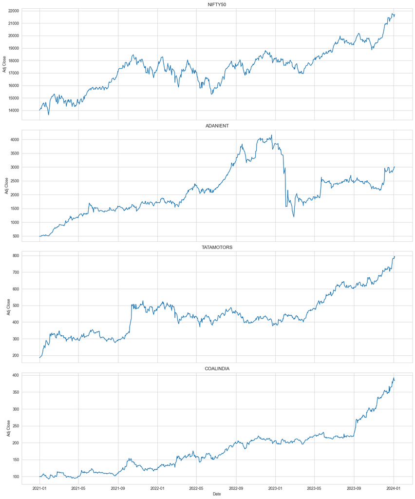

```python
fig, axes = plt.subplots(nrows=4, ncols=1, figsize=(15,18), sharex=True)

col = final_df.columns

sns.lineplot(x=col[0], y=col[1], data=final_df, ax=axes[0])
axes[0].set_title(col[1])
axes[0].set_ylabel('Adj Close')

sns.lineplot(x=col[0], y=col[2], data=final_df, ax=axes[1])
axes[1].set_title(col[2])
axes[1].set_ylabel('Adj Close')

sns.lineplot(x=col[0], y=col[3], data=final_df, ax=axes[2])
axes[2].set_title(col[3])
axes[2].set_ylabel('Adj Close')

sns.lineplot(x=col[0], y=col[4], data=final_df, ax=axes[3])
axes[3].set_title(col[4])
axes[3].set_ylabel('Adj Close')


plt.tight_layout()
plt.show()
```

`

## Daily Return Line Plot

```python
final_df = nifty.stock_info_df
final_df.reset_index(inplace=True)

final_df = final_df[['Date', 'Adj Close']]
final_df = final_df.rename(columns={'Adj Close': 'NIFTY50'})
final_df['NIFTY50 DR'] = final_df['NIFTY50'].pct_change()

final_df.head()
```

|  | Date | NIFTY50 | NIFTY50 DR |
| --- | --- | --- | --- |
| 0 | 2021-01-01 | 14018.500000 | NaN |
| 1 | 2021-01-04 | 14132.900391 | 0.008161 |
| 2 | 2021-01-05 | 14199.500000 | 0.004712 |
| 3 | 2021-01-06 | 14146.250000 | -0.003750 |
| 4 | 2021-01-07 | 14137.349609 | -0.000629 |

```python
top3_stocks = summary['Stock'].values

for item in top3_stocks:
    df = Stock(ticker=item+'.NS', start_date=start_date, end_date=end_date)
    df = df.stock_info_df
    df = df.reset_index()
    df = df[['Date', 'Adj Close']]
    df = df.rename(columns={'Adj Close': item})
    col = item + ' DR'
    df[col] = df[item].pct_change()
    final_df = final_df.merge(df, how='inner', on='Date')
```

```
[*********************100%%**********************]  1 of 1 completed
[*********************100%%**********************]  1 of 1 completed
[*********************100%%**********************]  1 of 1 completed
```

```python
final_df.head()
```

|  | Date | NIFTY50 | NIFTY50 DR | ADANIENT | ADANIENT DR | TATAMOTORS | TATAMOTORS DR | COALINDIA | COALINDIA DR |
| --- | --- | --- | --- | --- | --- | --- | --- | --- | --- |
| 0 | 2021-01-01 | 14018.500000 | NaN | 490.370636 | NaN | 185.920547 | NaN | 99.329117 | NaN |
| 1 | 2021-01-04 | 14132.900391 | 0.008161 | 493.715332 | 0.006821 | 190.705627 | 0.025737 | 100.723450 | 0.014038 |
| 2 | 2021-01-05 | 14199.500000 | 0.004712 | 493.615479 | -0.000202 | 192.599716 | 0.009932 | 99.182335 | -0.015300 |
| 3 | 2021-01-06 | 14146.250000 | -0.003750 | 490.121063 | -0.007079 | 194.792877 | 0.011387 | 99.145645 | -0.000370 |
| 4 | 2021-01-07 | 14137.349609 | -0.000629 | 517.277832 | 0.055408 | 196.138702 | 0.006909 | 100.173073 | 0.010363 |

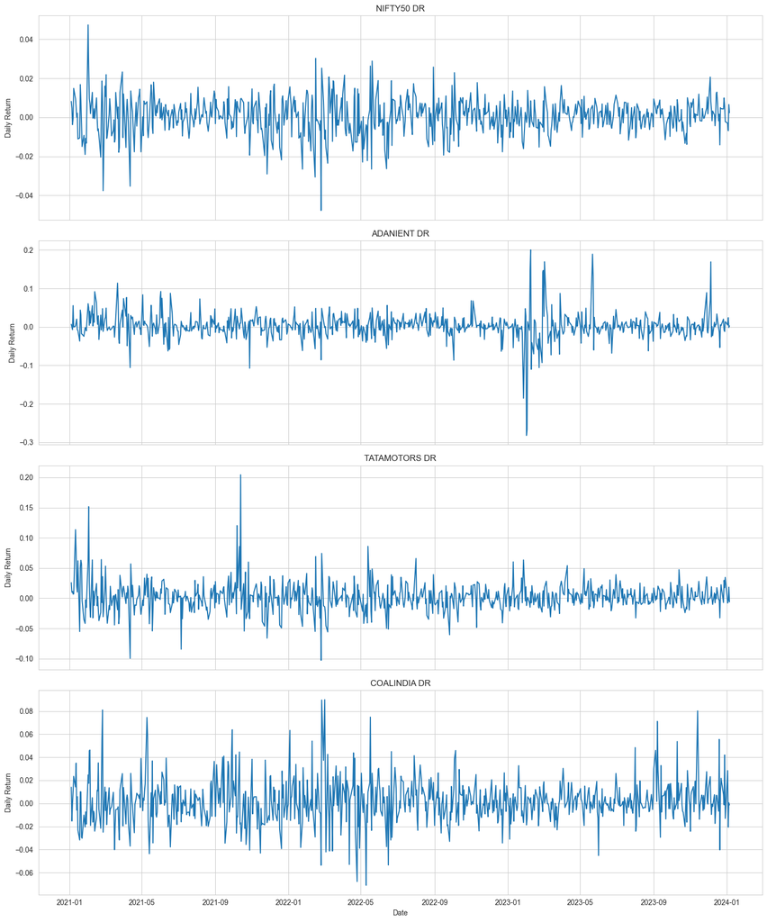

```python
fig, axes = plt.subplots(nrows=4, ncols=1, figsize=(15,18), sharex=True)

col = final_df.columns

sns.lineplot(x=col[0], y=col[2], data=final_df, ax=axes[0])
axes[0].set_title(col[2])
axes[0].set_ylabel('Daily Return')

sns.lineplot(x=col[0], y=col[4], data=final_df, ax=axes[1])
axes[1].set_title(col[4])
axes[1].set_ylabel('Daily Return')

sns.lineplot(x=col[0], y=col[6], data=final_df, ax=axes[2])
axes[2].set_title(col[6])
axes[2].set_ylabel('Daily Return')

sns.lineplot(x=col[0], y=col[8], data=final_df, ax=axes[3])
axes[3].set_title(col[8])
axes[3].set_ylabel('Daily Return')


plt.tight_layout()
plt.show()
```

`